# Introduction to R

Andreas Santucci

# Loading Data

We often want to start by loading some data into R. There are several basic ways. We may use the `read.table` command to read from a variety of different inputs. For example, we can read data from a web-page.

```r
data <- read.table('http://www.stats.ox.ac.uk/pub/datasets/csb/ch11b.dat')
head(data)
```

```
##   V1  V2   V3    V4 V5
## 1  1 307  930 36.58  0
## 2  2 307  940 36.73  0
## 3  3 307  950 36.93  0
## 4  4 307 1000 37.15  0
## 5  5 307 1010 37.23  0
## 6  6 307 1020 37.24  0
```

# Inspecting Data

What are the dimensions of our data?

```r
dim(data)
```

```
## [1] 100   5
```

When our data is read, it is converted to a type of object in R called a `data.frame`. This is a way to hold a collection of vectors (numeric, character, or mixed) each the same length but possibly different types. We may index the rows and columns easily

```r
data[3:10, 2:ncol(data)]
```

```
##     V2   V3    V4 V5
## 3  307  950 36.93  0
## 4  307 1000 37.15  0
## 5  307 1010 37.23  0
## 6  307 1020 37.24  0
## 7  307 1030 37.24  0
## 8  307 1040 36.90  0
## 9  307 1050 36.95  0
## 10 307 1100 36.89  0
```

We might wish to know how our data are *structured*, in which case we may use the `str` command.

```r
str(data)
```

```
## 'data.frame':    100 obs. of  5 variables:
##  $ V1: int  1 2 3 4 5 6 7 8 9 10 ...
##  $ V2: int  307 307 307 307 307 307 307 307 307 307 ...
##  $ V3: int  930 940 950 1000 1010 1020 1030 1040 1050 1100 ...
##  $ V4: num  36.6 36.7 36.9 37.1 37.2 ...
##  $ V5: int  0 0 0 0 0 0 0 0 0 0 ...
```

This tells us the dimensions of our data, the column names, their respective data-types, and the first few entries in each column. We might also apply the `summary` function to learn several statistics of our data.

```r
summary(data)
```

```
##        V1               V2              V3             V4
##  Min.   :  1.00   Min.   :307.0   Min.   :   0   Min.   :36.58
##  1st Qu.: 25.75   1st Qu.:307.0   1st Qu.:1128   1st Qu.:37.15
##  Median : 50.50   Median :307.0   Median :1535   Median :37.73
##  Mean   : 50.50   Mean   :307.1   Mean   :1446   Mean   :37.60
##  3rd Qu.: 75.25   3rd Qu.:307.0   3rd Qu.:1942   3rd Qu.:37.98
##  Max.   :100.00   Max.   :308.0   Max.   :2350   Max.   :38.35
##        V5
##  Min.   :0.00
##  1st Qu.:0.00
##  Median :1.00
##  Mean   :0.62
##  3rd Qu.:1.00
##  Max.   :1.00
```

# Visualizing Data

We can easily display graphical summaries of our data using basic commands like `hist` and `plot` for histograms and two-way scatter plots respectively.

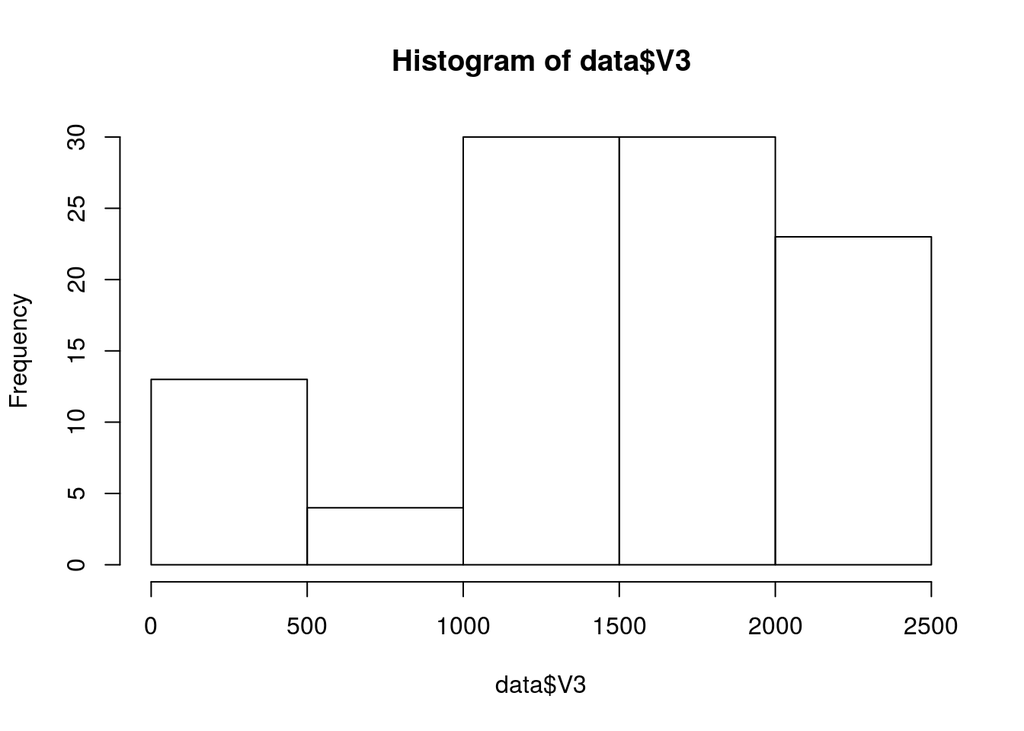

```r
hist(data$V3)
```

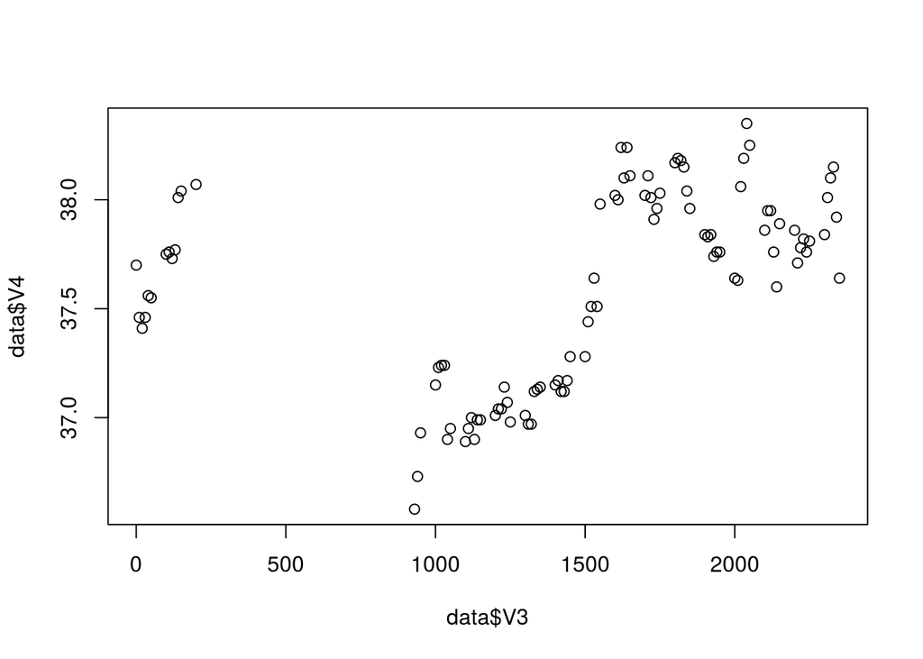

```r
plot(data$V3, data$V4)
```